# Quantitative Genetics – PCB6555

Pedigree Analysis

Felipe Ferrão and Marcio Resende Jr

University of Florida – October, 2020

**Recapping:**

- We initially expressed genotypic means, breeding value and genotypic variance as a function of allele frequencies and genotypic values.
- Using genetic designs we were able to distangle the causal variance components.
- So far, we assume independence between the genetic effects.

**Plan for today:**

- Incorporate pedigree information to estimate genetic components and predict the breeding values
- Run the so-called animal model in asreml-R

# 1 Theory

## 1.1 Introduction

In the last section, we discussed how via progenie tests we could estimate genetic components and predict the breeding values. To this end, we used a prior knowledge of the resemblance between relatives and experimental statistics to predict the breeding values for the parents and offsprings (or families). As a fundamental assumption, we assume that all individuals are independent; that we know that is not a fair assumption, since most breeding populations are composed by individuals that are genetically correlated.

So, why use pedigree information?

- Statistically, random genetic effects (i.e. BLUPs) are not independent and their matrix of correlations or co-variances needs to be specified.
- Genetically, it is important to consider information about relatives as they will share some alleles, and therefore their response is correlated.

## 1.2 How to incorporate pedigree information?

Exploitation of pedigree information in animal breeding is mostly based on the numerator relationship matrix. Usually denoted as **A**, which is computed from the **coefficient of coancestry** $\theta_{xy}$ between genotypes *x* and *y* as $A = {2\theta_{xy}}$, assuming relativer are not inbreed. The matrix that indicates the additive genetic relationship among individuals is called the **numerator relationship matrix (A)**.

**Important aspects of the A matrix:**

- It is a symmetric matrix.
- Diagonal element is equal to $1 + F_i$, and hence values larger than 1 can be an indication of inbreeding.
- The off-diagonal element, $a_{ij}$ , equals the numerator of the coefficient of relationship between animals *i* and *j*.

**Example:**

- In the example below:
  - Individuals 1 and 6: coefficient between parent-offspring (0.5)
  - Individuals 7 and 8: full-sibs (0.5)
  - Individuals 13-14: half-sibs (0.25)
  - There is no inbreeding

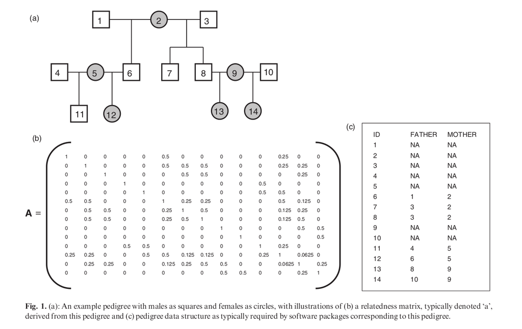

Example of A matrix from Wilson et al., 2010

## 1.3 Brief theoretical background on BLUPs

Henderson (1949) developed a methodology called best linear unbiased prediction (BLUP), by which fixed effects and breeding values can be simultaneously estimated. The properties of BLUP are more or less incorporated in the name:

- **B**est: means it maximizes the correlation between true and predicted breeding value or minimizes prediction error variance (PEV).
- **L**inear: predictors are linear functions of observations.
- **U**nbiased – estimation of realized values for a random variable and of estimable functions of fixed effects are unbiased.
- **P**rediction – involves prediction of true breeding value.

In a matrix format, we have the following mixed model:

$$y = Xb + Zu + e$$

where **y** represents a vector of observed (measured) phenotype values, **b** and **u** are vectors of unknown parameters for “fixed” and “random” effects, while **X** and **Z** are corresponding design matrices and finally **e** is a vector of residuals. The covariance matrix of additive effect can be written as $G=A\sigma^2_u$, where **A** is additive/numerator relationship matrix and $\sigma^2_u$ is additive genetic variance.

One of Henderson’s remarkable invention was the so-called mixed model equations (MME) to estimate solutions **b** (fixed effects solutions) and predict solutions for random effects **u** simultaneously. The MME for equation are:

$$\begin{bmatrix} {X'R^{-1}X} & {X'R^{-1}Z} \\ {Z'R^{-1}X} & {Z'R^{-1}Z} + {A^{-1}\lambda} \end{bmatrix}
\begin{bmatrix} {\hat{b}}\\ {\hat{u}} \end{bmatrix}
=
\begin{bmatrix} {X'R^{-1}y} \\ {Z'R^{-1}y} \end{bmatrix}$$

$$\hat{b} = (X'V^{-1}X)^{-1}XV^{-1}y$$

$$\hat{u} = GZ'V^{-1}(y-X\hat{b})$$

### 1.3.1 Numerical Example

#### 1.3.1.1 Example 3.1 from Mrode (2014)

- The objective is to estimate the fixed effects of sex and predict the breeding values for all animals. Assuming that $\sigma^2_a=20$ and $\sigma^2_e$=40. The model to describe the observations is: $y_{ij}=p_i+ a_j+e_{ij}$, where *p* is the fixed effect of sex and *a* is the random effect of the calf.

| Calves | Sex | Sire | Dam | WWG |
| --- | --- | --- | --- | --- |
| 4 | male | 1 | unknown | 4.5 |
| 5 | female | 3 | 2 | 2.9 |
| 6 | female | 1 | 2 | 3.9 |
| 7 | male | 4 | 5 | 3.5 |
| 8 | male | 3 | 6 | 5 |

**Solutions**

| males | females | 1 | 2 | 3 | 4 | 5 | 6 | 7 | 8 |
| --- | --- | --- | --- | --- | --- | --- | --- | --- | --- |
| 4.358 | 3.404 | 0.098 | -0.019 | -0.041 | -0.009 | -0.186 | 0.177 | -0.249 | 0.183 |

```r
#----------------------------------------#
# Henderson's Equation
#----------------------------------------#

# data set
sigmaE <- 40
sigmaA <- 20
alpha  <- sigmaE / sigmaA

# Data
calf   <- c(4:8)
sex    <- c("male", "female", "female", "male", "male")
WWG    <- c(4.5, 2.9, 3.9, 3.5, 5.0)
data.3.1 <- data.frame(calf, sex, WWG)

# Pedigree
calf    <- c(1:8)
sire    <- c(NA, NA, NA, 1, 3, 1, 4, 3)
dam     <- c(NA, NA, NA, NA, 2, 2, 5, 6)
ped.3.1 <- data.frame(calf, sire, dam)

# pedigree() function to create pedigree S4 object
library(pedigreemm)
ped.complete <- pedigree(sire= ped.3.1$sire,
                           dam= ped.3.1$dam,
                           label= ped.3.1$calf)
A <- getA(ped.complete)

# Matrices
X <- matrix(c(0,1,1,0,0,
              1,0,0,1,1), ncol=2)
Z <- matrix(c(0,0,0,0,0,
              0,0,0,0,0,
              0,0,0,0,0,
              1,0,0,0,0,
              0,1,0,0,0,
              0,0,1,0,0,
              0,0,0,1,0,
              0,0,0,0,1), ncol=8)

# Calculate blocks of LHS
y = WWG
XpX = crossprod(X)
ZpZ = crossprod(Z) + (solve(A) * alpha)
XpZ = crossprod(X, Z)
XpY = crossprod(X, y)
ZpY = crossprod(Z, y)
LHS = rbind(cbind(XpX, XpZ),  cbind(t(XpZ), ZpZ))
RHS = rbind(XpY, ZpY)
solutions = solve(LHS) %*% RHS
```

**Notes:**

### 1.3.2 Bonus

In the last classes we demonstrated how to compute the coefficient of coancestry using path coefficients.

Herein, we will present a numerical example on how to compute the **A** matrix using a recursive method proposed by Henderson (1976). Below, there is an example of recursive algorithm as presented by Mrode (2014):

  **Example 2.1 from Chapter2 in Mrode (2014)**

  For example, assume that the data below is the pedigree for six animals.

| Calf | Sire | Dam |
| --- | --- | --- |
| 3 | 1 | 2 |
| 4 | 1 | Unknown |
| 5 | 4 | 3 |
| 6 | 5 | 2 |

- $a_{11} = 1+0 = 1$
- $a_{12} = 0.5(0+0) = 0 = a_{21}$
- $a_{22} = 1+0 = 1$
- $a_{13} = 0.5(a_{11}+a_{12}) = 0.5(1+0) = 0.5 = a_{31}$
- $a_{23} = 0.5(a_{12}+a_{22}) = 0.5(0+1) = 0.5 = a_{32}$
- …
- $a_{34} = 0.5(a_{13}) = 0.5(0.5+0) = 0.25 = a_{43}$
  - …
- $a_{66} = 1 + (0.5)(a_{52}) = 1+0.5(0.25) = 1.125$

  The numerator relationship matrix for the example pedigree is:

  |  | 1 | 2 | 3 | 4 | 5 | 6 |
  | --- | --- | --- | --- | --- | --- | --- |
  | 1 | 1 | 0 | 0.5 | 0.5 | 0.5 | 0.25 |
  | 2 | 0 | 1 | 0.5 | 0 | 0.25 | 0.625 |
  | 3 | 0.5 | 0.5 | 1 | 0.25 | 0.625 | 0.563 |
  | 4 | 0.5 | 0 | 0.25 | 1 | 0.625 | 0.313 |
  | 5 | 0.5 | 0.25 | 0.625 | 0.625 | 1.125 | 0.688 |
  | 6 | 0.25 | 0.625 | 0.563 | 0.313 | 0.688 | 1.125 |

**Using a R function**

- Author: Gota Morota
- [Link](http://morotalab.org/Mrode2005/relmat/relmat.html#section00020000000000000000)

```r
         ## Given the vectors of sire and dam, return additive relationship matrix 'A'.

         ## Arguments
         ## s: a vector of sire
         ## d: a vector of dam

         ## Note: Unknown parents should be coded as zero.

         ## Literature: Henderson, C. R. 1976. Simple Method for Computing the Inverse of a Numerator Relationship Matrix Used in Prediction of Breeding Values. Biometrics 32:69-83.

         ## Author: Gota Morota <morota at wisc dot edu>
         ## Created: 16-Apr-2009
         ## Last-Modified: 1-Apr-2010
         ## License: GPLv3 or later

         `createA` <-
           function(s, d){
             if (nargs()==1){
               stop("sire vector and dam vector are required")
             }

             if (length(s) != length(d)){
               stop("size of the sire vector and dam vector are different!")
             }

             n <- length(s)
             N <- n + 1
             A <- matrix(0, ncol=N, nrow=N)

             s <- (s == 0)*(N) + s
             d <- (d == 0)*N + d

             for(i in 1:n){

               A[i,i] <- 1 + A[s[i], d[i]]/2

               for(j in (i+1):n){
                 if (j > n) break
                 A[i,j] <- ( A[i, s[j]] + A[i,d[j]] )/2
                 A[j,i] <- A[i,j]
               }
             }

             return(A[1:n, 1:n])

           }

         s = c(0,0,1,1,4,5)
         d = c(0,0,2,0,3,2)
         createA(s,d)
```

**Using R packages**

- There are different R packages that can also be used to compute to compute A matrix in different formats.
- Example:
- AGHmatrix (`Amatrix`) – [link](https://github.com/prmunoz/AGHmatrix)
- Pedigree (`makeA`) – [link](https://www.rdocumentation.org/packages/pedigree/versions/1.4)
- Pedigreem (`getA`) – [link](https://cran.r-project.org/web/packages/pedigreemm/index.html)
- synbreed (`kin`) – [link](https://www.rdocumentation.org/packages/synbreed/versions/0.12-9)

# 2 Practice

- Half-sib analysis without pedigree
- Half-sib analysis using pedigree information
- Animal model using deep and a shallow pedigree

## 2.1 Half sib family

### 2.1.1 Example

- Download the provenance progeny test (`Pine_provenance.csv`) and the pedigree information (`pine-provenance_pedigree.txt`). An example from [Isik et al., 2017](https://www.springer.com/gp/book/9783319551753).
  - [Link for the example](https://drive.google.com/drive/folders/0B9JWAJgh6v3Cflppc09XUXU3WHRvX29qY1IxNDVFaEdpblA4SFNXOThQV2ZDRVkxWlZWSEk).
  - Original Description: A provenance-progeny test of a pine species was established. The maternal parent of each tree was known, but the seeds were derived from open-pollination (random outcrossing) of those female parents, so the male parents of each tree were not known. This represents a half-sib mating design within each provenance. There are four provenances and 36 half-sib families in total. The field experimental design was a RCBD design with five blocks and from two to six trees measured within each plot. Data are given for each tree.

| Effect | Observation | Levels |
| --- | --- | --- |
| treeid | A unique tree ID | 914 |
| female | Mother tree | 36 |
| prov | Provenance number (tree origin) | 4 |
| block | block number | 5 |
| plot | experimental unit | - |
| height | response variable | numeric |

### 2.1.2 Postulating a Family Model

$$y_{ijk} = \mu + \underline{B_i} + P_j + \underline{F_{k(j)}} + \underline{BF_{ik(j)}} + \underline{e_{ijkl}}$$

- $\mu$ is the overall mean;
- $P_j$ = fixed effect of provenance *j*
- $B_i$ = random effect of block *i*, where $B_i \sim N(0, I\sigma^2_b)$
- $F_j$ = random effect of female *j*, where $F_{j} \sim N(0, I\sigma^2_g)$
- $BF_{ik(j)}$ = random effect of interaction between block *i* and female *k* nested in provenance group *j* (this is the plot effect), where $BF_{ik(j)} \sim N(0, I\sigma^2_{b \times g})$
- $e_{ijk}$ = random effect error, distributed as: $e_{ijk} \sim N(0, I\sigma^2_e)$

**`asreml-R` codes**

```r
#############
# Half sib model
##########
library(asreml)
library(asremlPlus)
hf = read.csv("/home/lferrao/Dropbox/classes/2020/QuantitativeGenetics/week8_Animal Model/Pine_provenance.csv")
table(hf$female, hf$block)

# factors
hf$treeid = as.factor(hf$treeid)
hf$female = as.factor(hf$female)
hf$block = as.factor(hf$block)
hf$prov = as.factor(hf$prov)
hf$plot = as.factor(hf$plot)

# Modelling
m1<-asreml(fixed=height~prov,
           random=~ female  + block + block:female ,
           data=hf)

summary(m1)$varcomp
plot(m1)

# Adj means
adj.mean = predict(m1,classify='female')$pvals # adjusted mean (original scale)
adj.mean %>%
  arrange(desc(predicted.value)) %>%
  head() # top females

# Additive h2
vpredict(m1,h2~(4*V2)/(V1+V2+V3+V4))
```

### 2.1.3 Postulating the Animal Model

**Notes**

- Predict BVs of grandparents, progeny and parents simultaneously.
- Requires a genetic relationship matrix.
- The main difference from the family model is that we have a `tree` effect in the model instead of `Female` (or Family) effect.
- Also, compared to the last model, since we have the effects of individual trees instead of families, we cannot easily model the plot effect.
- Nomenclature: `vm(obj, source)`, that creates a term based on obj with known variance structure in source

**Animal Model**

$$y_{ijk} = \mu + \underline{B_i} + P_j + \underline{T_k} + \underline{e_{ijk}}$$

- $\mu$ is the overall mean;
- $P_j$ = fixed effect of provenance *j*
- $B_i$ = random effect of block *i*, where $B_i \sim N(0, I\sigma^2_b)$
- $T_k$ = random effect of tree *k*, where $T_j \sim N(0, A\sigma^2_g)$ and **A** is a numerator pedigree matrix.
- $e_{ijk}$ = random effect error, distributed as: $e_{ijk} \sim N(0, I\sigma^2_e)$

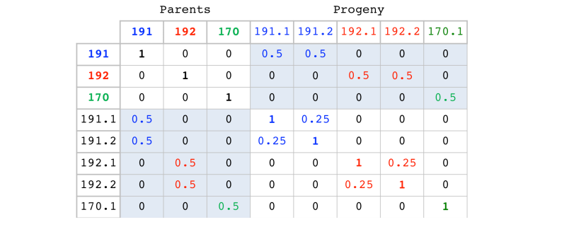

A matrix for three parent and selected open-pollinated progenies

```r
#############
# Animal model
##########
# Importing the pedigree
ped<-read.table("/home/lferrao/Dropbox/classes/2020/QuantitativeGenetics/week8_Animal Model/pine_provenance_pedigree.txt",
                h=T, colClasses = c("factor", "factor", "factor"))
ped1 = data.frame(treeid = ped$treeid, male = 0,female = ped$female ) # non information from the dad
ainvIND<-ainverse(ped1) # Generates an A inverse

# Modelling
m2<-asreml(fixed=height~prov,
           random=~ block+ vm(treeid,ainvIND),
           data=hf)
plot(m2)
summary(m2)$varcomp
vpredict(m2,h2~(V2)/(V1+V2+V3)) # do not multiply by 4

# Ranking
adj.mean2 = predict(m2,classify='treeid')$pvals
head(adj.mean2)

# Female ranking
# Animal Model
adj.mean2 %>%
  filter(treeid %in% adj.mean$female) %>%
  arrange(desc(predicted.value)) %>%
  head() # top females

# Half Sib model
adj.mean %>%
  arrange(desc(predicted.value)) %>%
  head() # top females

# Ploting
BVmerged =merge(adj.mean, adj.mean2, by.x = "female", by.y = "treeid")
plot(BVmerged$predicted.value.x, BVmerged$predicted.value.y) # similar results

# Selecting individuals
adj.mean2[-c(1:40),] %>%
  arrange(desc(predicted.value)) %>%
  head() # top females
```

### 2.1.4 Animal Model vs. Family Model

|  | Family Model | Animal Model |
| --- | --- | --- |
| Model | female effect | individual tree effect |
| Pedigree | no | yes |
| Objective | Backward selection | Backward and forward selection |
| Narrow sense h2 | 0.26 | 0.30 |
| Residual Variance | 2.52 | 2.01 |
| Breeding values | female | female + individuals |

## 2.2 Animal Model with Deep Pedigree

- Previous example was limited since the pedigree was quite shallow, covering only two generations. – open-pollination and we had no information on the fathers.
- We now turn to an example from the animal science with information across more generations and record from male and females

### 2.2.1 Example

- Download the pig data set (`pig_data.txt`) and the pedigree information (`pig_pedigree.txt`). An example from [Isik et al., 2017](https://www.springer.com/gp/book/9783319551753).
  - [Link for the example](https://drive.google.com/drive/folders/0B9JWAJgh6v3Cflppc09XUXU3WHRvX29qY1IxNDVFaEdpblA4SFNXOThQV2ZDRVkxWlZWSEk).
  - Original Description: pig breeding population evaluated for different years. Pedigree information on the pigs in this data set from seven generations, corresponding to historical years of evaluation.

| Effect | Observation | Levels |
| --- | --- | --- |
| pig | A unique pig ID | 2556 |
| sire | Father | 153 |
| dam | Mother | 498 |
| year | Evaluation year | 6 |
| sex | Pig’s sex | 3 |
| weanage | Age in weeks at which pig was weaned | numeric |
| weanwt | Weight at weaning | numeric |

### 2.2.2 Postulating the Animal Model

$$y_{ijk} = \mu + Y_i + S_j + W_k + \underline{P_{l}} + \underline{e_{ijkl}}$$

- $\mu$ is the overall mean;
- $Y_i$ = fixed effect of year *j*
- $S_j$ = fixed effect of pig’ sex
- $W_k$ = fixed covariate for weaning age
- $P_l$ = random effect of pig *l*, where $P_l \sim N(0, A\sigma^2_g)$ and **A** is a numerator pedigree matrix.
- $e_{ijkl}$ = random effect error, distributed as: $e_{ijk} \sim N(0, I\sigma^2_e)$

```r
#############
# Animal model
##########
# Importing the pedigree
ped_pig<-read.table("/home/lferrao/Dropbox/classes/2020/QuantitativeGenetics/week8_Animal Model/pig_pedigree.txt",
                h=T, colClasses = c("factor", "factor", "factor"))
head(ped_pig)
tail(ped_pig) # information from dam and sire

# A inverse
ainvIND<-ainverse(ped_pig)

# Importing the data set
pig_data<-read.table("/home/lferrao/Dropbox/classes/2020/QuantitativeGenetics/week8_Animal Model/pig_data.txt",
                h=T)
head(pig_data)
table(pig_data$pig, pig_data$year)

# Factors
pig_data$pig = as.factor(pig_data$pig)
pig_data$year = as.factor(pig_data$year)
pig_data$sex = as.factor(pig_data$sex)
pig_data$sire = as.factor(pig_data$sire)
pig_data$dam = as.factor(pig_data$dam)
str(pig_data)

# Modelling the Complete Pedigree
# General Nomenclature: vm(factor,Amatrix)
m3<-asreml(fixed=weanwt~year + sex + weanage,
           random=~ vm(pig,ainvIND) ,
           data=pig_data)
plot(m3)
summary(m3)$varcomp
vpredict(m3,h2~(V1)/(V1+V2))

# Pedigree fake
# Fake pedigree, removing information from dad
ped_fake<-read.table("/home/lferrao/Dropbox/classes/2020/QuantitativeGenetics/week8_Animal Model/pig_pedigree_fake.txt",
                h=T, colClasses = c("factor", "factor", "factor"))
head(ped_fake)
tail(ped_fake) # information from dam and sire
ainvIND_fake<-ainverse(ped_fake)

# Modelling the Fake Pedigree
m4<-asreml(fixed=weanwt~year + sex + weanage,
           random=~ vm(pig,ainvIND_fake) ,
           data=pig_data)

# Comparing both models
library(asremlPlus)
infoCriteria(m3)
infoCriteria(m4)

# Ranking
adj.mean3 = predict(m3,classify='pig')$pvals
adj.mean4 = predict(m4,classify='pig')$pvals

adj.mean3 %>%
  arrange(desc(predicted.value)) %>%
  head()

adj.mean4 %>%
  arrange(desc(predicted.value)) %>%
  head()

plot(adj.mean3$predicted.value,adj.mean4$predicted.value) # drastic change

# What is happening when genetic effects are considered independent?
m5<-asreml(fixed=weanwt~year + sex + weanage,
           random=~ pig,
           data=pig_data)
# Singularities in the average information matrix
```

# 3 Final Considerations

- Animal model provides predictions for all individuals in a given population (granparents, parents and offspring) in one step.
- Breeding values are comparable across all generations because they are on the same scale.
- It provides a prediction even if an individual does not have a measured phenotype, since pedigree information allows to borrow information between relatives.
- In the next classes, we will see that pedigree model is the basis for more complex genetic models, including the use of dominance effects, GxE interaction, mating desing, maternal effect and genomic selection.

# 4 References

- Robinson, 1991. That BLUP is a good thing: The estimation of Random Effects [Paper link](https://projecteuclid.org/euclid.ss/1177011926) – BLUP derivation
- Wilson et al., (2009). An ecologist’s guide to the animal model [Paper link](https://besjournals.onlinelibrary.wiley.com/doi/10.1111/j.1365-2656.2009.01639.x) – Gentle introduction about Animal Models
- Isik et al., 2017. Genetic Data Analysis for Plant and Animal Breeding. [Book link](https://www.springer.com/gp/book/9783319551753)
- Mrode, 2014. Linear Models for the Prediction of Animal Breeding Values. [Book link](https://www.amazon.com/Linear-Models-Prediction-Animal-Breeding/dp/1845939816)
- Falconer and Mackay, 1996. Introduction to Quantitative Genetics. [Book link](https://www.amazon.com/Introduction-Quantitative-Genetics-Douglas-Falconer/dp/0582243025)

[figure not shown]